# Web Scraping with R: Assignment - 3

Ghazal Ayobi

# Paris Restaurants

Paris is a big city and attracts many tourists. Thus, for this purpose I would like to use [**Yelp Website**](https://www.yelp.ie) to compare and contrast the available restaurants prices, number of reviews and opening hours. In order to scrape all the data in the website I undertook the following steps.

In the second part of the project, I created another function, which gathered each restaurant details which is called *get_each_restaurant*. For this purpose I created an empty list called *t_list*, I used this link to put each node data. This function contains the following information for all restaurant: *Restaurant name number of views, price level, amenities, phone number, address, and opening hours for each day of the week.* While scraping these nodes I came across many issues. For example, in this Yelp website each restaurant has information whether these restaurants are claimed by the owner or not. If restaurant is claimed by the owner it will be written *Claimed* if it is not claimed by the owner, it will be written as *Unclaimed*. The interesting part is the HTML node for the *pricing level* contains information about *Unclaimed* restaurants but not the claimed ones. First, I tried to use *html_node* to address this issue. However, I was not successful. The *html_node* function for the specific node only returned information about *Unclaimed* but not the Price. Thus, I decided to use *html_nodes* function for the pricing level node. Thus, I further cleaned the data. Second, while scraping the phone number, the html node differed from one restaurant to the other. This reason for this was restaurants *phone number, link and address* details are added in one table, For some of the restaurants the restaurant link section was missing. Thus, it the HTML nodes change from the restaurants with website link details and without website link details part. Consequently, I scraped the node where I received all of the information about the restaurant website, phone number and address. I used *sub* function to clean the list, and by this way I extracted the phone number. The other problem that I came across was opening hours. In the beginning, I decided to created a *for* loop to put opening hours of each restaurant for each day of the week. However, after multiple attempts, I received errors which showed that some restaurants have multiple shifts and different hours. For example, one restaurant has one morning and one evening shift.Thus, there were more nodes for the opening and closing hours of some restaurants for one day. For this purpose I dropped the *for* loop function. As a result of many attempts, I decided to scrape the complete opening hours table and extract hours for each day. The codes are provided in the following section.

In the third step, I created a vector of all the links from the data frame from the first function where I extracted name and link of the restaurant. I used the *lapply* function on the *get_each_restaurant* function and the list of links from the restaurants names data frame.

While using *get_each_restaurant* function, I got multiple error and session timeout, as a result I decided to scrape first restaurants details in small numbers. I scraped restaurants in groups of 50, 20 and 10 restaurants. As a result of the above functions, I created a data frame which includes each restaurant name, number of views, pricing level, amenities, phone number, address, and opening hours for each day. As mentioned above, the pricing level had data about unclaimed restaurants, in the data cleaning process, I excluded *Unclaimed* from price level and created another data frame for all of the restaurants which are not claimed by the owner to a data frame called *unclaimed_res*.

As a result, I created four visualizations which is shown below. Figure 1 indicates that there are many restaurants with second and third level prices. Figure 2 indicates the histogram of number of reviews which shows that more than half of the restaurants have lower reviews which has a right skewed distribution. Figure 3 illustrates the relationship between price level and number of reviews. This indicates that restaurants with two to three price level have more reviews. At last, I wanted to see what the relationship between price level and number of reviews for closed restaurants. Thus, as a result restaurants except first price level and on average with lower reviews are closed on Sundays.

```r
#Cleaning the environment
rm(list = ls())

#Libraries

library(rvest)
library(data.table)
library(httr)
library(xml2)
library(data.table)
library(tidyverse)
library(ggplot2)
```

```r
scrape_data <- function(url) {

paris_url <- read_html(url)

# Creating relative links
relative_link <- paris_url %>% html_nodes('.css-1uq0cfn .css-1422juy') %>% html_attr('href')

# Create links of the website
links <- paste0('https://www.yelp.ie', relative_link)

# Creating elements
name <- paris_url %>% html_nodes('.css-1uq0cfn .css-1422juy') %>% html_text()

# Create Data frame and put everything together
df <- data.frame('Name' = name, 'links' = links)

return(df)
}
```

```r
# Selecting multiple pages
links <- paste0('https://www.yelp.ie/search?find_desc=Restaurants&find_loc=Paris%2C+France&start=', c(0, 10, 20, 30, 40, 50, 60, 70, 80, 90, 100, 110, 120, 130, 140, 150, 160, 170, 180, 190, 200, 210, 220, 230))

# Apply the function
list_of_dfs <- lapply(links, scrape_data)
df2 <- rbindlist(list_of_dfs, fill = T)
write_csv(df2, 'restaurants_all_list.csv')
```

```r
get_each_restaurant <- function(url2) {
  t <- read_html(url2)
t_list <- list()
t_list[['name']] <- t %>% html_nodes('.css-1x9iesk') %>% html_text()
reviews <- t %>% html_nodes('.arrange-unit-fill__09f24__CUubG.nowrap__09f24__lBkC2 .css-1yy09vp') %>% html_text()
t_list[['n_views']] <- sub(" reviews", "", reviews)
t_list[['pricing']] <- t %>% html_nodes('.css-oyv5ea') %>% html_text()
t_list[['amenities']] <- t %>% html_nodes('.layout-2-units__09f24__PsGVW') %>% html_text()
phone <- t %>% html_node('.border-radius--regular__09f24__MLlCO') %>% html_text()
phone <- sub(".*Phone number", "", phone)
t_list[['number']] <- substr(phone, 1, 14)
t_list[['address']] <- t %>% html_nodes('.vertical-align-middle__09f24__zU9sE .css-1ccncw') %>% html_text()
table <- t %>% html_node('.table--simple__09f24__vy16f') %>% html_text()
t_list[['monday']] <- sub("Tue.*", "", table)
tuesday <- sub("Wed.*", "", table)
t_list[['tuesday']] <- sub(".*Tue", "", tuesday)
wednesday <-  sub("Thu.*", "", table)
t_list[['wednesday']] <- sub(".*Wed", "", wednesday)
thursday <- sub("Fri.*", "", table)
t_list[['thursday']] <- sub(".*Thu", "", thursday)
friday <- sub("Sat.*", "", table)
t_list[['friday']] <- sub(".*Fri", "", friday)
saturday <- sub("Sun.*", "", table)
t_list[['saturday']] <- sub(".*Sat", "", saturday)
t_list[['sunday']] <- sub(".*Sun", "", table)
return(t_list)
}
```

```r
df3 <- df2[1:50, ]
df4 <- df2[51:100, ]
df5 <- df2[101:150, ]
df6 <- df2[151:170, ]
df7 <- df2[171:190, ]
df8 <- df2[191:210, ]
df9 <- df2[211:230, ]
df10 <- df2[231:240, ]
url3 <- df3$links
url4 <- df4$links
url5 <- df5$links
url6 <- df6$links
url7 <- df7$links
url8 <- df8$links
url9 <- df9$links
url10 <- df10$links


rest_list <- lapply(url3, get_each_restaurant)
rest_df <- rbindlist(rest_list, fill = T)

rest_list4 <- lapply(url4, get_each_restaurant)
rest_df4 <- rbindlist(rest_list4, fill = T)

rest_list5 <- lapply(url5, get_each_restaurant)
rest_df5 <- rbindlist(rest_list5, fill = T)

rest_list6 <- lapply(url6, get_each_restaurant)
rest_df6 <- rbindlist(rest_list6, fill = T)

rest_list7 <- lapply(url7, get_each_restaurant)
rest_df7 <- rbindlist(rest_list7, fill = T)

rest_list8 <- lapply(url8, get_each_restaurant)
rest_df8 <- rbindlist(rest_list8, fill = T)


rest_list9 <- lapply(url9, get_each_restaurant)
rest_df9 <- rbindlist(rest_list9, fill = T)

rest_list10 <- lapply(url10, get_each_restaurant)
rest_df10 <- rbindlist(rest_list10, fill = T)

restaurant_details <- rbind(rest_list, rest_list4,rest_df5,rest_df6, rest_df7, rest_df8, rest_df9, rest_df10)
write_csv(restaurant_details, 'each_restaurant_details.csv')
```

```r
# Uploading data from GitHub
restaurants_list <- read_csv("https://raw.githubusercontent.com/ghazalayobi/web_scraping/main/raw/assignment3/restaurants_all_list.csv")
restaurants_details <- read_csv("https://raw.githubusercontent.com/ghazalayobi/web_scraping/main/raw/assignment3/each_restaurant_details.csv")
```

```r
# Cleaning the data

restaurants_details$n_views <- gsub(" review", "", restaurants_details$n_views)

restaurants_details$monday <- gsub("^.{0,3}", "", restaurants_details$monday)

restaurants_details$n_views <- as.numeric(restaurants_details$n_views)
restaurants_details$saturday <- gsub("Closed now", "", restaurants_details$saturday)
restaurants_details$saturday <- gsub("Open now", "", restaurants_details$saturday)

unclaimed_res <- subset(restaurants_details, pricing == "Unclaimed")
restaurants_details <- subset(restaurants_details, pricing != "Unclaimed")
restaurants_details$pricing <- as.factor(restaurants_details$pricing)
```

## Visualizations

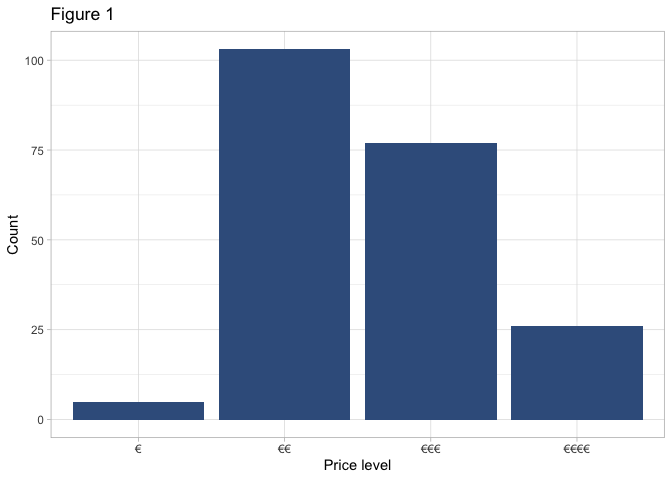

```r
graph1 <- ggplot(data = restaurants_details, aes(x = pricing )) +
  geom_bar(fill = "#3a5e8cFF" ) +
  labs(x = "Price level",y = "Count")+
  theme_light() +
  ggtitle("Figure 1")
graph1
```

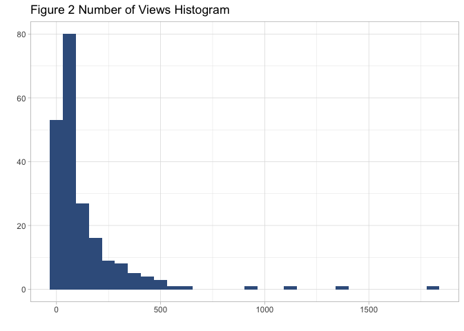

```r
graph2 <- ggplot(data = restaurants_details, aes(x = n_views)) +
  geom_histogram(fill = "#3a5e8cFF") +
  labs(x = "",y = "")+
  theme_light() +
  ggtitle("Figure 2 Number of Views Histogram")
graph2
```

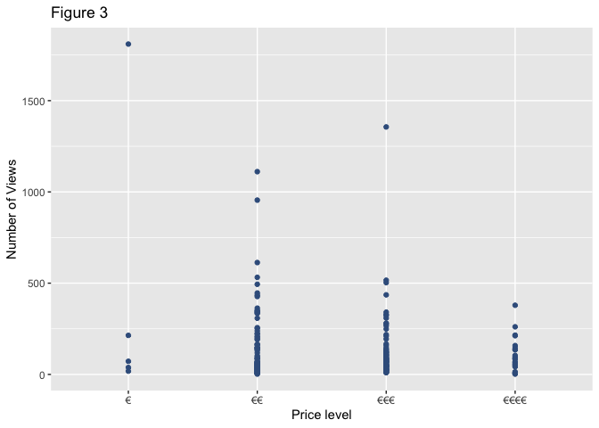

```r
graph3 <- ggplot(restaurants_details, aes(x = pricing, y = n_views)) +
  labs(x = "Price level",y = "Number of Views")+
  geom_point(color = "#3a5e8cFF") +
  ggtitle("Figure 3")

graph3
```

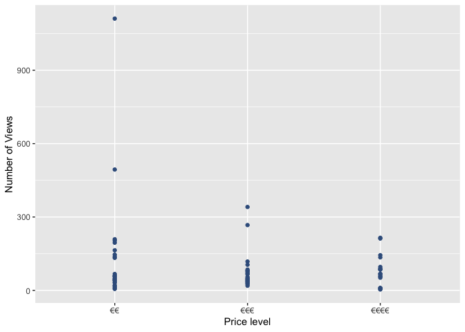

```r
closed <- restaurants_details %>% filter(restaurants_details$sunday == "Closed")
closed <- as.data.frame(closed)
graph4 <- ggplot(closed, aes(x = pricing, y = n_views)) +
  labs(x = "Price level",y = "Number of Views")+
  geom_point(color = "#3a5e8cFF")
graph4
```